# ShaaficiSection

# An investigation into the relationship between particulate damage and emissions

## Definition

Long Definition: “Particulate emissions damage is the damage due to exposure of a country’s population to ambient concentrations of particulates measuring less than 2.5 microns in diameter (PM2.5), ambient ozone pollution, and indoor concentrations of PM2.5 in households cooking with solid fuels. Damages are calculated as foregone labor income due to premature death. Estimates of health impacts from the Global Burden of Disease Study 2016. Data for other years have been extrapolated from trends in mortality rates.” –World bank researcher

## Statistical concepts used in collecting the data

" Within the national accounting framework, air pollution damages are estimated following a human capital approach. Damages from premature mortality are calculated as the present value of lost income during working age, 15-64. Premature mortality among children is valued by adjusting for years until working age and discounting more heavily into the future. Estimates are for both urban and rural areas. Exposure to household air pollution is proxied by the number of households in each country cooking with solid fuels." –world bank researcher

## Why its relevant to developement

“Air pollution places a major burden on world health. In many places, including cities but also nearby rural areas, exposure to air pollution exposure is the main environmental threat to health. Long-term exposure to high levels of fine particulates in the air contributes to a range of health effects, including respiratory diseases, lung cancer, and heart disease, resulting in 3.2 million deaths annually according to the Global Burden of Disease 2010 study. Not only does exposure to air pollution affect the health of the world’s people, it also carries huge economic costs and represents a drag on development, particularly for low and middle income countries and vulnerable segments of the population such as children and the elderly.” - World Bank researcher

## Authors Limitations

“Labor productivity losses, as calculated within the framework of adjusted net savings, represent only part of the economic costs of air pollution and should be interpreted as a lower-end estimate.” - World Bank researcher

## Reasoning

As the researcher stated in limitations, this provides an low end estimate of air pollution damage and exploring the relationship between emissions and particulate damage can help give a view between emissions and some of the damage it causes.

Emissions was measured as total CO2

There was a choice to choose between the particulate damage cost in terms of US$ or from the percentage of GNI%. GNI stands for Gross National Income and it is a measure of all the money earned as income from businesses and people. GNI gave a better measure of the relative burden then US dollars would have. If a coal miner and a billionare both lost $50,000, the absolute value would be the same but the impact would be completely different.This logic was used in making this decision, not all countries have similar wealth so the *impact* must be measured.

In general the impact has been going down. An arima forecast of 25 years shows the tragectory of particulate damage for the average particulate damage per country.

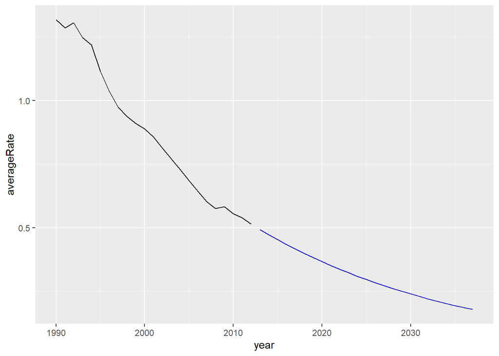

```r
fcplot
```

## View of the world.

A cross correlation was built for every country/territory in the world that is recognized by the world bank. The countries were put into 5 categories

1.No correlation

2.Positive correlation with increasing emissions

3.Positive correlation with decreasing emissions

4.Negative correlation with increasing emissions

5.Negative correlations with decreasing emissions

## Results

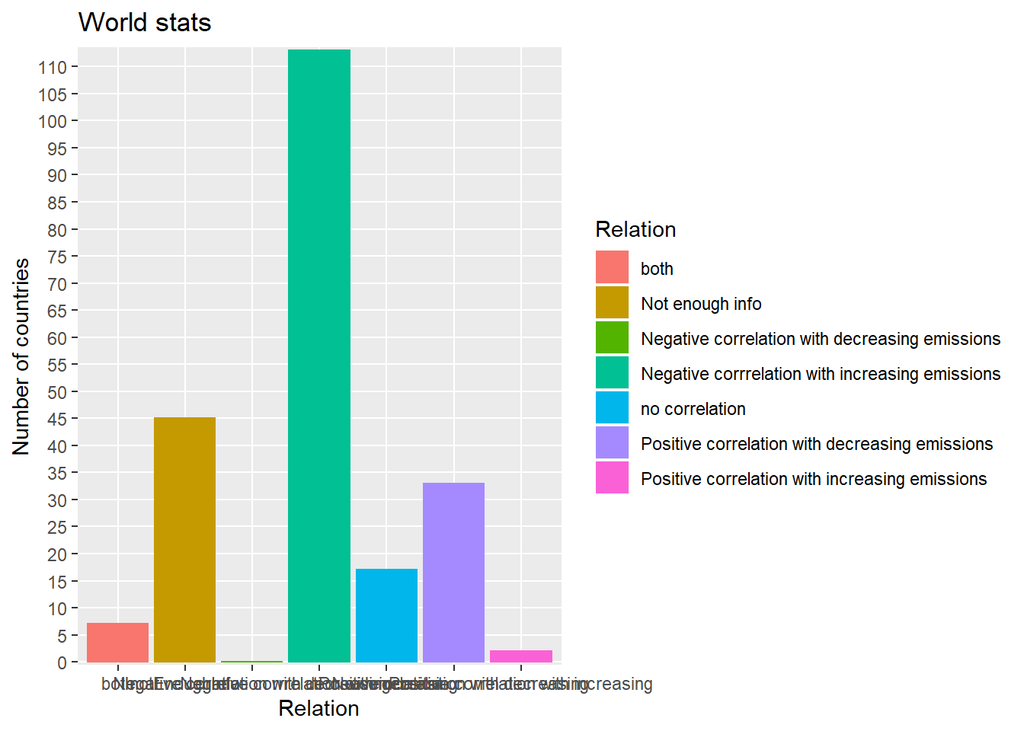

```r
WorldRelationPlot
```

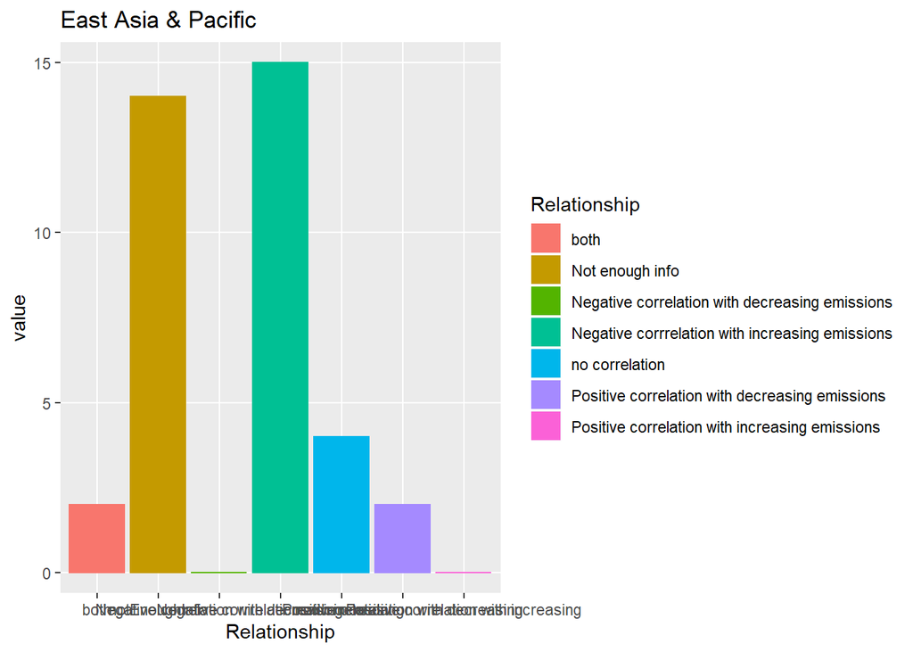

```r
EastAsiaPacificBar
```

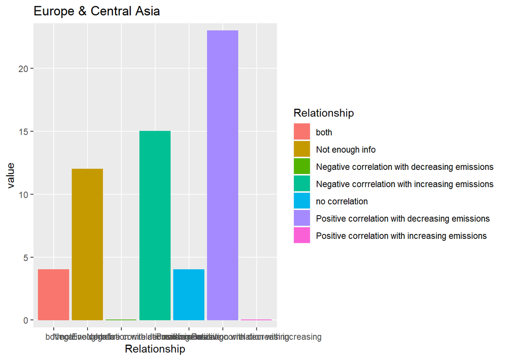

```r
EuropeCentralAsiaBar
```

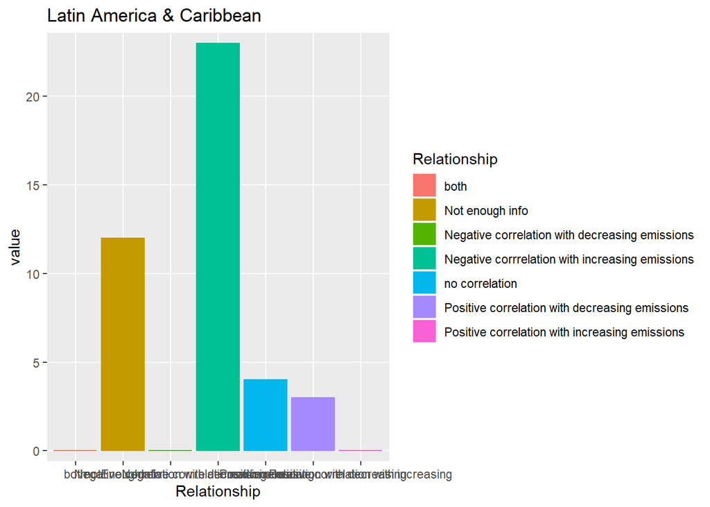

```r
LatinAmericaCaribbeanBar
```

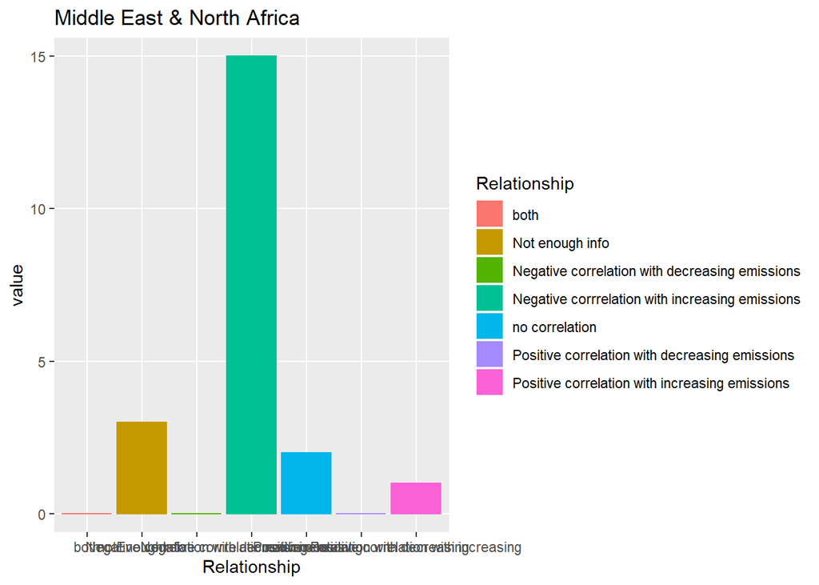

```r
MiddleEastAfricaBar
```

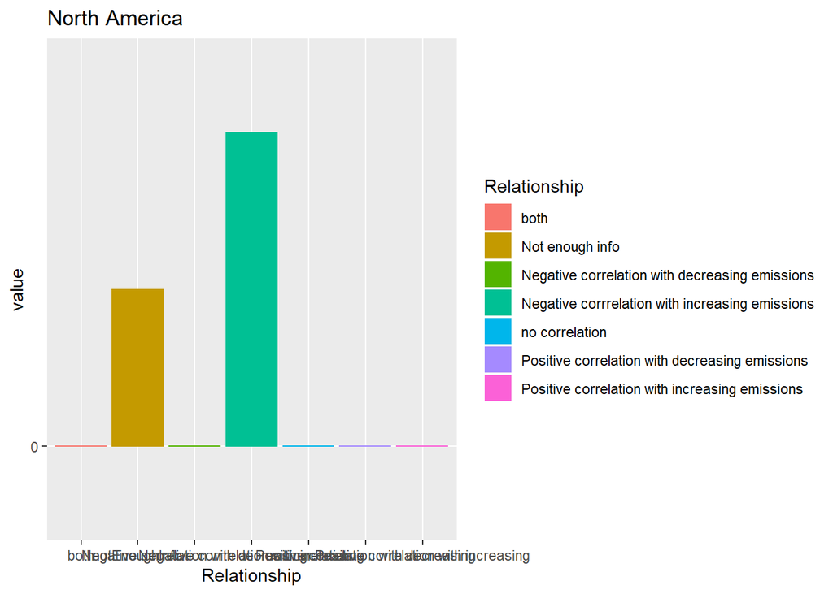

```r
NorthAmericaBar
```

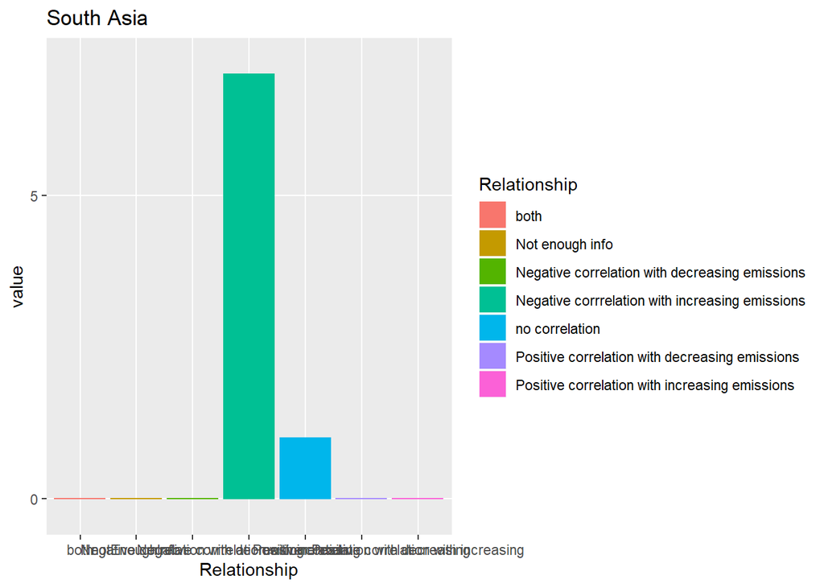

```r
SouthAsiaBar
```

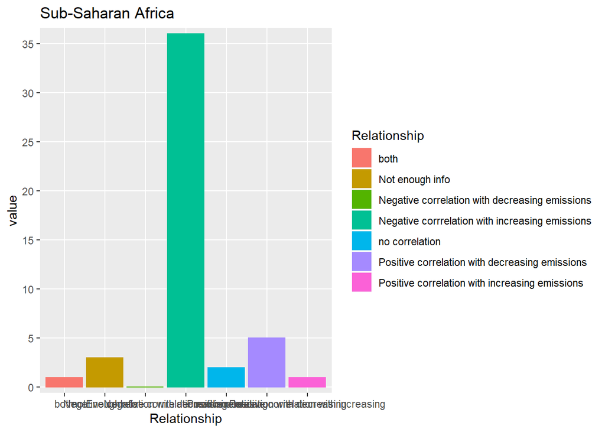

```r
SubSaharaAfricaBar
```

```r
world %>% tm_shape() + tm_fill(col = "Relationship",palette = c("purple","blue","grey","black","red","green"))
```

```
## Some legend labels were too wide. These labels have been resized to 0.55, 0.62, 0.63, 0.61. Increase legend.width (argument of tm_layout) to make the legend wider and therefore the labels larger.
```

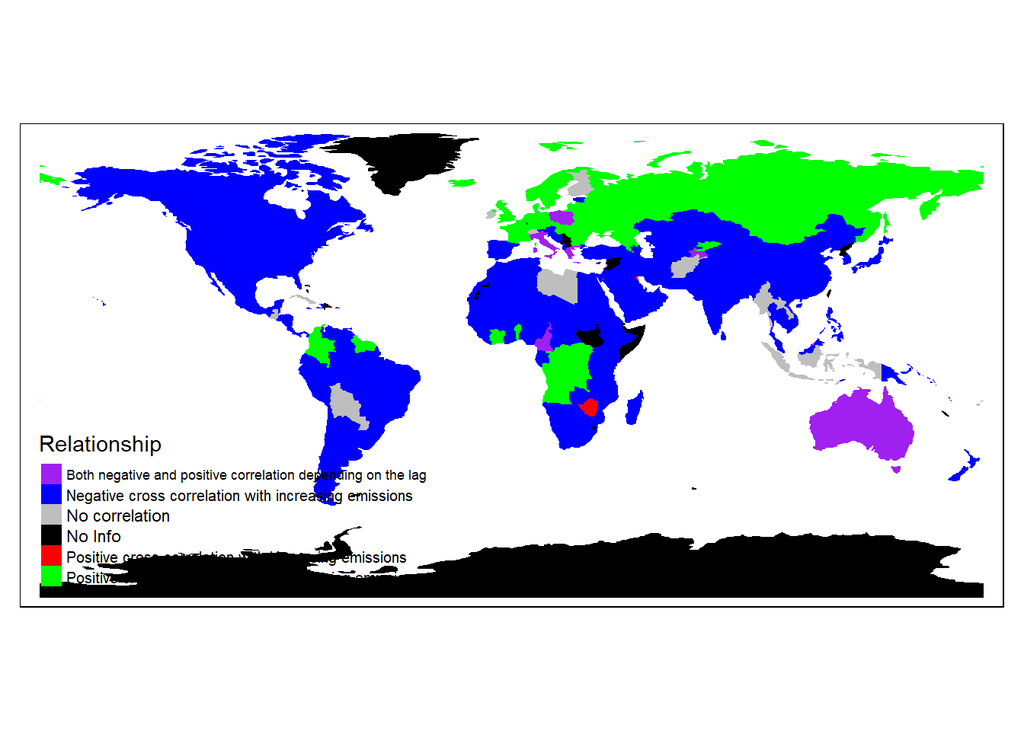

```r
Africa
```

```
## Some legend labels were too wide. These labels have been resized to 0.35, 0.40, 0.40, 0.39. Increase legend.width (argument of tm_layout) to make the legend wider and therefore the labels larger.
```

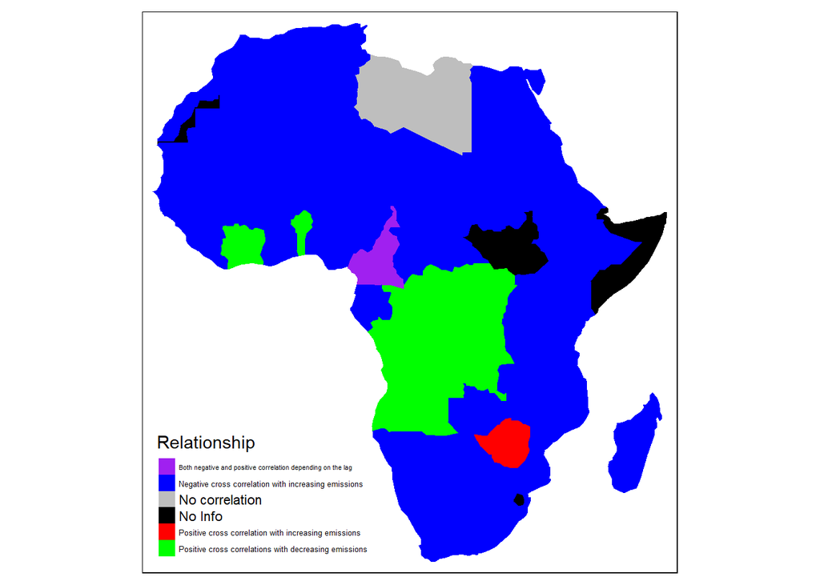

```r
Asia
```

```
## Some legend labels were too wide. These labels have been resized to 0.55, 0.62, 0.63, 0.61. Increase legend.width (argument of tm_layout) to make the legend wider and therefore the labels larger.
```

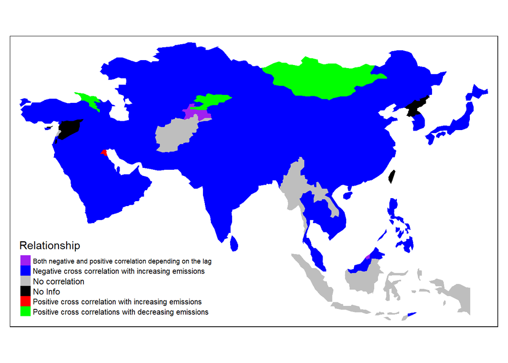

```r
Europe
```

```
## Some legend labels were too wide. These labels have been resized to 0.55, 0.62, 0.61. Increase legend.width (argument of tm_layout) to make the legend wider and therefore the labels larger.
```

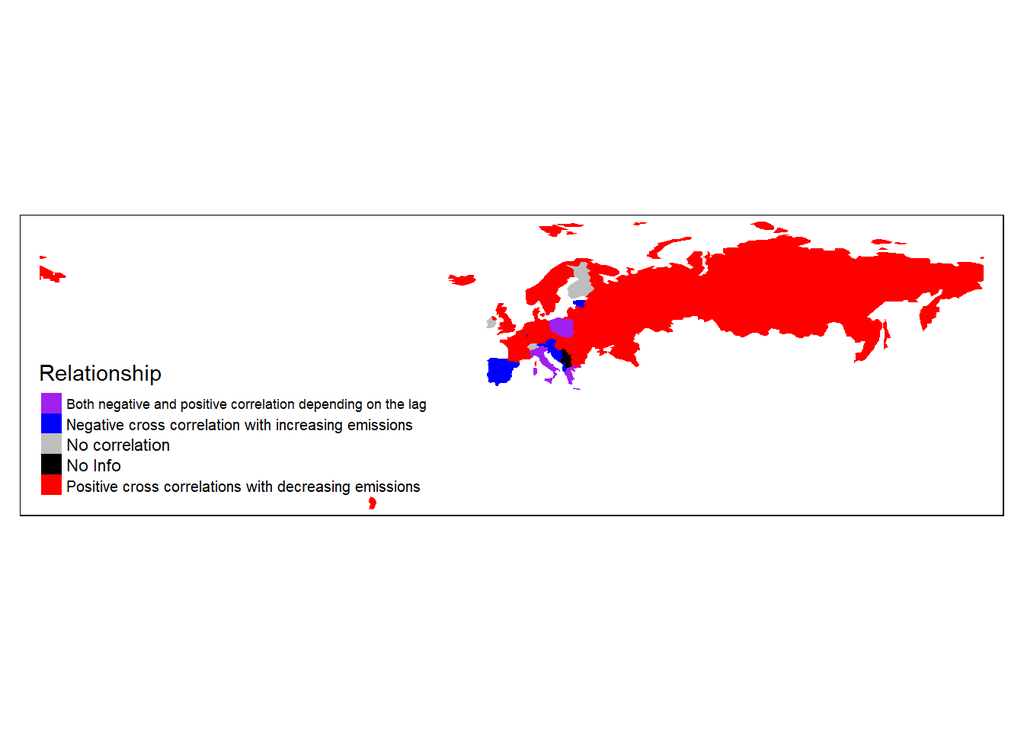

```r
NorthAmerica
```

```
## Some legend labels were too wide. These labels have been resized to 0.62. Increase legend.width (argument of tm_layout) to make the legend wider and therefore the labels larger.
```

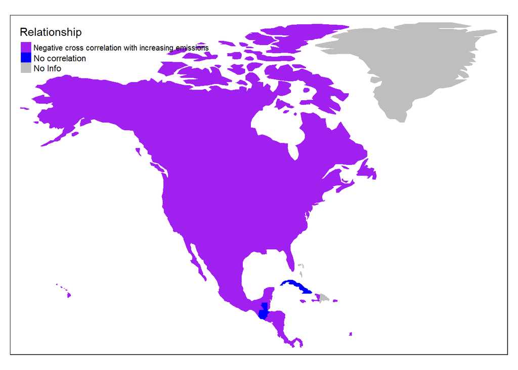

```r
Oceania
```

```
## Some legend labels were too wide. These labels have been resized to 0.55, 0.62. Increase legend.width (argument of tm_layout) to make the legend wider and therefore the labels larger.
```

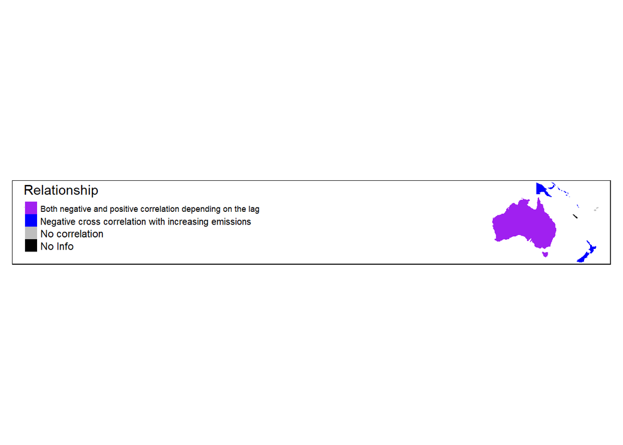

```r
SouthAmerica
```

```
## Some legend labels were too wide. These labels have been resized to 0.24, 0.24. Increase legend.width (argument of tm_layout) to make the legend wider and therefore the labels larger.
```

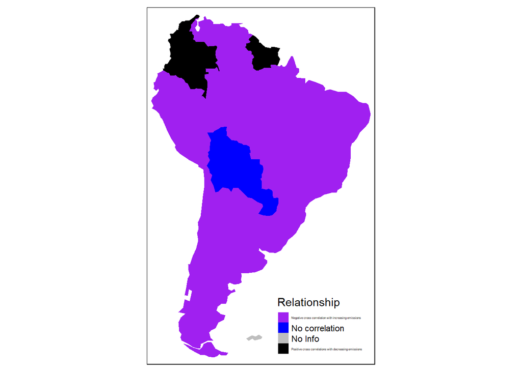

All these countries are not independent of each other. By doing a cross correlation over 200 times we run into *multiple comparisons problem*. The multiple comparisons problem is when multiple hypothesises are tested,the likelyhood of a wrong inference/outlier result increases. We need to correct for that and in order to do so we need to first understand how significance of cross correlations are calculated.

The significance levels for a cross correlation with a 0.05 threshold is calculated by $\frac{2}{\sqrt{observations}}$ Observations in this case are all the years that have both particulate damage and emissions. A country was said to be positively correlated if there existed a lag year that had passed the significance relationship. There were some countries that had a positive correlation with some lags and also had a negative correlation with others. In general this was the break down of how the countries were categorized.

1.positive correlation 2.negative correlation 3.both 4.no correlation

```r
TrueResults
```

```
## # A tibble: 1 x 4
##    both positive negative  none
##   <int>    <int>    <int> <int>
## 1     7       28      113    17
```

In general cross correlations significance level follows a normal distribution along 0 with a standard deviation of $\frac{2}{\sqrt{observations} * 2}$ because that previous number was for 95% confidence interval, which is two standard deviations, so halfing it will give us a good sd to use for simulations.

After running the experiment 1000 times These were the results for each category.

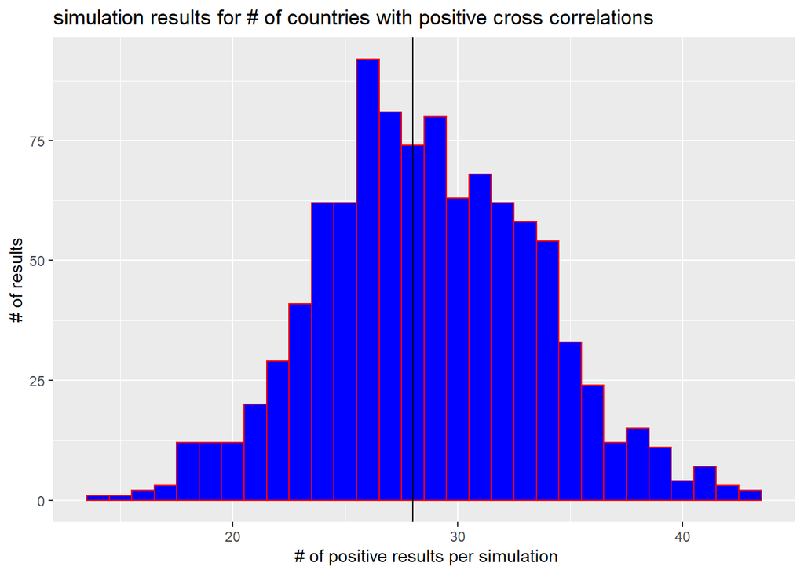

```r
PosHist
```

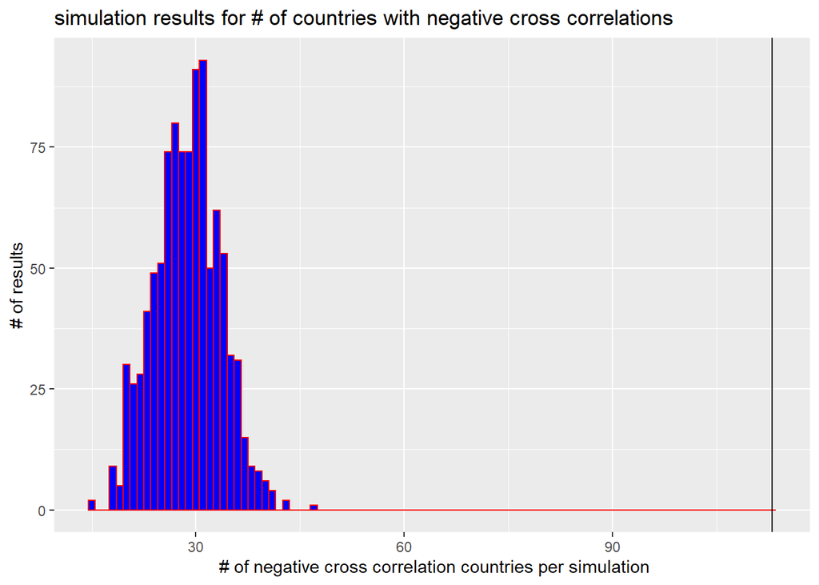

```r
NegHist
```

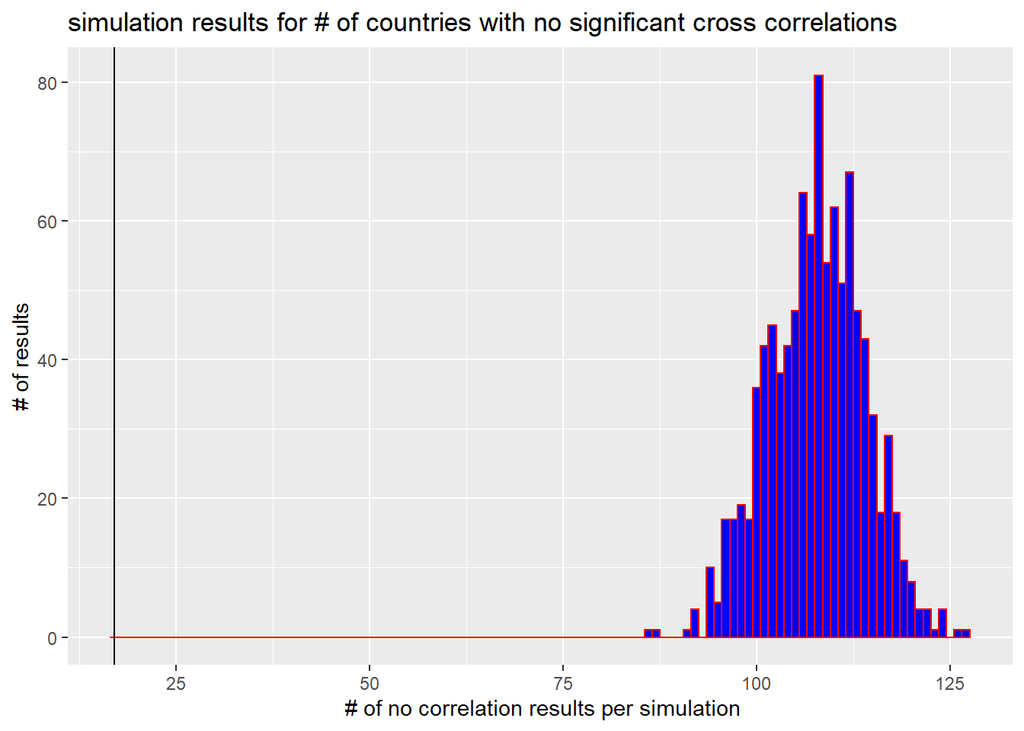

```r
noneHist
```

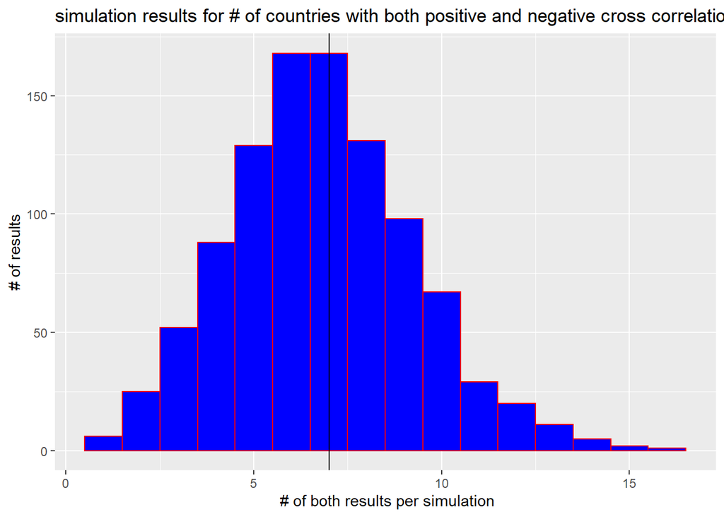

```r
bothHist
```

The actual results for each category is that black line shown. Using Dunn-Sidak correction the actual values must be either smaller than or equal to the bottom 3.108201410^{-4} percent of simulations or greater than or equal to 0.9996892 percent. The categories “both” and “positive” cross correlations are well within those ranges and we cannot determine if these results are not just due to chance and are not random.

But Negative cross correlations are significantly higher than all other simulated values and no cross correlations are significantly lower. Therefor we can say that a relationship is there.